# Final Project

Antonietta

May 07 2021

# The data:

We will be filtering the data set so that it includes only the variables of interest.

```r
ny_cases <- covid_data %>%
  filter(name == "New York") %>%
  select(total_prisoner_cases, total_prisoner_deaths, prisoners_recovered, total_staff_cases, as_of_date)
```

# Summary of simple statistics for the variables of interest.

```r
ny_cases %>%
  group_by(total_prisoner_cases, total_prisoner_deaths) %>%
  summarise(across(c(total_staff_cases),
    list(
      mean = ~ mean(.x, na.rm = TRUE),
      sd = ~ sd(.x, na.rm = TRUE),
      min = ~ min(.x, na.rm = TRUE),
      max = ~ max(.x, na.rm = TRUE))))
```

```
## # A tibble: 51 x 6
## # Groups:   total_prisoner_cases [51]
##    total_prisoner_… total_prisoner_… total_staff_cas… total_staff_cas…
##               <dbl>            <dbl>            <dbl>            <dbl>
##  1                3                0               40               NA
##  2               20                1              147               NA
##  3               62                2              381               NA
##  4              160                5              664               NA
##  5              239                6              844               NA
##  6              370               10             1045               NA
##  7              415               15             1143               NA
##  8              443               16             1192               NA
##  9              471               16             1228               NA
## 10              493               16             1275               NA
## # … with 41 more rows, and 2 more variables: total_staff_cases_min <dbl>,
## #   total_staff_cases_max <dbl>
```

# Main plot: this plot looks at the tootal cases of COVID-19 in New York prisoners

[figure not shown]

```r
main_plot <- ny_cases %>%
  ggplot(aes(x = as_of_date,
      y = total_prisoner_cases)) +
  geom_point(alpha= 5,
             shape= 20,
             color="#C8A2C8",
        fill= "#C8A2C8") +
  scale_y_continuous("Prisoners COVID-19 Cases") +
  scale_x_discrete("Date") +
  ggtitle("New York Prisoners' COVID-19 Cases") +
  theme_light()


main_plot
```

# Staff & Prisoners plot: this plot looks at the total cases of COVID-19 in New York prisoners as well as the total cases of COVID-19 in the prison’s staff

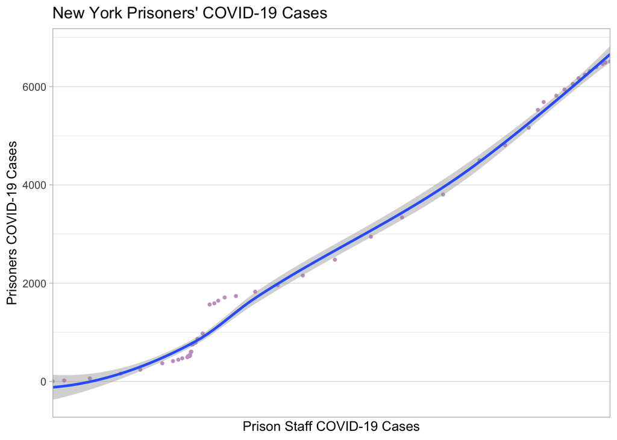

```r
staff_prisonersplot <- ny_cases %>%
  ggplot(aes(x = total_staff_cases,
      y = total_prisoner_cases)) +
  geom_point(alpha= 5,
             shape= 20,
             color="#C8A2C8",
        fill= "#C8A2C8") +
  geom_smooth(method = "loess") +
  scale_y_continuous("Prisoners COVID-19 Cases") +
  scale_x_discrete("Prison Staff COVID-19 Cases") +
  ggtitle("New York Prisoners' COVID-19 Cases") +
  theme_light()

staff_prisonersplot
```

# Staff & Prisoners plot: this plot looks at the total cases of COVID-19 in New York prisoners as well as the total number of recovered prisoners

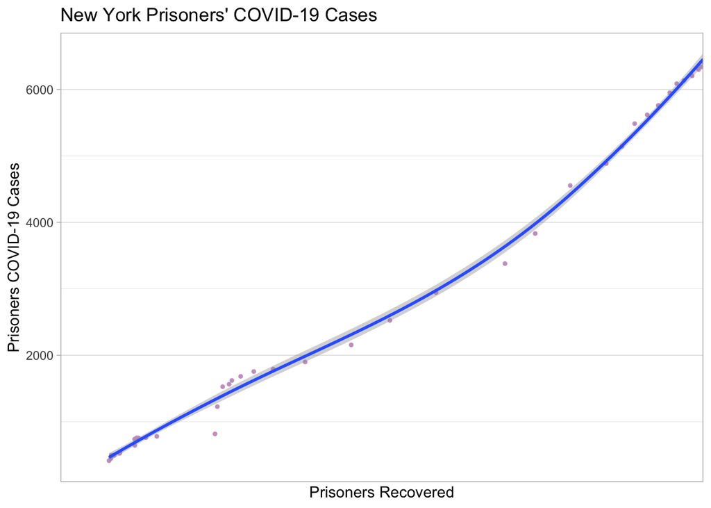

```r
prisoners_recoveryplot <- ny_cases %>%
  ggplot(aes(x = total_prisoner_cases,
      y = prisoners_recovered)) +
  geom_point(alpha= 5,
             shape= 20,
             color="#C8A2C8",
        fill= "#C8A2C8") +
  geom_smooth(method = "loess") +
  scale_y_continuous("Prisoners COVID-19 Cases") +
  scale_x_discrete("Prisoners Recovered") +
  ggtitle("New York Prisoners' COVID-19 Cases") +
  theme_light()

prisoners_recoveryplot
```